# Rodando um modelo linear

Delineamento e Estatística

Nicholas A. C. Marino

github.com/nacmarino/metodosR

## Modelos lineares

- Rodar um modelo é parte ciência, parte arte:
  - O modelo segue sua pergunta e/ou desenho experimental;
  - Não existe o modelo certo, mas sim o que se adequa aos seus dados;
  - Você não vai ter apenas um modelo para trabalhar, mas vários modelos possíveis (eu normalmente rodo > 30 modelos para cada variável resposta nos meus trabalhos);
  - Achar o modelo adequado vem primeiro, a significância (estatística) do que está dentro dele vem depois.

## Passo-a-passo (minha fórmula)

> 1. Saber o que quero fazer;
> 2. Visualizar os dados e relação entre eles;
> 3. Descobrir o tipo de distribuição da minha variável resposta;
> 4. Estabelecer um modelo nulo;
> 5. Criar um modelo:
>    - adicionando uma variável de interesse por vez; ou,
>    - com todas as variáveis de interesse de uma vez.
> 6. Comparar com o modelo nulo;
> 7. Adicionar/remover variáveis do modelo;
> 8. Comparar os novo(s) modelo(s);
> 9. Determinar o modelo mais provável;
> 10. Validar modelo final;
> 11. Testar significância dos termos no modelo;
> 12. Fazer pós-testes, se necessário.

### Não confudir normalidade dos dados *vs* normalidade dos resíduos!

- General Linear Models: distribuição dos resíduos do modelo segue a distribuição de probabilidade normal (`lm`, `glm::gaussian`).
- General__ized__ Linear Models: distribuição dos resíduos do modelo não segue a distribuição de probabilidade normal (`glm`).

## Um exemplo ilustrativo de um modelo linear generalizado

- A relação espécie-área (Arrhenius, 1921, J Ecol 9: 95-99) é uma das relações mais conhecidas e exploradas da ecologia.
- O estudo de Biogeografia de Ilhas, por MacArthur & Wilson (1967), foi uma grande contribuição para entendermos a dinâmica ecológica nestes habitats.
- Podemos usar essas informações como um ponto de partida para direcionar nossas análises:
  1. A riqueza de espécies em uma ilha aumenta como a sua área (log-log).
  2. A riqueza de espécies em uma ilha aumenta com a quantidade de energia disponível.
  3. A riqueza de espécies em uma ilha aumenta com a diversidade de habitats.
  4. Ilhas oceânicas possuem menor riqueza de espécies do que ilhas costeiras de mesmo tamanho.
  5. Ilhas em arquipelagos maiores devem ter mais espécies que em arquipelagos menores.

```r
ilhas <- read.table(file = "dados/ilhas.txt", header = TRUE)
head(ilhas)
```

```
##        ID     ilha arquipelago riqueza      area produtividade populacao
## 1  ilha_1 costeira       medio      21    1.5087      1.569027  268.0317
## 2 ilha_10 costeira       medio      27   22.4316      4.557252  258.6569
## 3 ilha_11 costeira     pequeno      23   41.0562      2.186004  281.4168
## 4 ilha_12 oceanica     pequeno      10 2134.7332   2012.823245  144.7503
## 5 ilha_13 costeira       medio      34 1004.7454    244.139993  515.5030
## 6 ilha_14 oceanica       medio      13   39.2341      3.169186  579.3220
##   habitat montanha mamiferos temperatura precipitacao
## 1       2      nao         7    24.19338    2125.2072
## 2       2      nao         9    21.81413    1623.7525
## 3       3      sim        10    18.34677    1995.0253
## 4       5      sim         6    11.38796    1655.7927
## 5       4      sim        13    23.93856    1497.2807
## 6       3      sim         3    23.22181     939.4002
```

- Vamos utilizar a função `glm` para explorar a relação entre o número de espécies em cada ilha (variável resposta) e as características de cada uma das ilhas (variáveis preditoras).
- A função `glm` é composta pelos seguintes argumentos:

```r
args(glm)
```

```
## function (formula, family = gaussian, data, weights, subset,
##     na.action, start = NULL, etastart, mustart, offset, control = list(...),
##     model = TRUE, method = "glm.fit", x = FALSE, y = TRUE, contrasts = NULL,
##     ...)
## NULL
```

- Podemos construir modelos de acordo com nossas hipóteses OU realizar uma seleção de modelos (faremos este último para a finalidade desta aula).
- O pacote `MuMin` possui um conjunto de funções muito úteis para realizarmos este processo, sendo a função `MuMin::drege` uma destas.
  - A primeira etapa é construir um modelo com todas as variáveis que queremos incluir e testar no processo de seleção de modelos;
  - A partir deste modelo global, o processo de seleção de modelos é realizado pela função `MuMin::drege`.
  - Existe a possibilidade ‘forçar’ a presença de determinadas variáveis em todos os modelos através do argumento `fixed`

```r
library(MuMIn)
options(na.action = na.fail) # necessário para que a função funcione - previne que os modelos sejam ajustados a conjuntos de dados diferentes
modelo <- glm(formula = log(riqueza) ~ arquipelago + log(area) + produtividade + populacao + habitat + montanha + temperatura + precipitacao,
              family = gaussian(), data = ilhas)
args(dredge)
```

```
## function (global.model, beta = c("none", "sd", "partial.sd"),
##     evaluate = TRUE, rank = "AICc", fixed = NULL, m.lim = NULL,
##     m.min, m.max, subset, trace = FALSE, varying, extra, ct.args = NULL,
##     ...)
## NULL
```

```r
selecao <- dredge(modelo)
selecao
```

```
## Global model call: glm(formula = log(riqueza) ~ arquipelago + log(area) + produtividade +
##     populacao + habitat + montanha + temperatura + precipitacao,
##     family = gaussian(), data = ilhas)
## ---
## Model selection table
##     (Int) arq        hbt log(are) mnt       ppl        prc        prd
## 8   4.096   + -0.8244000   0.3783
## 136 4.155   + -0.8227000   0.3787
## 16  4.086   + -0.8136000   0.3798   +
## 40  4.067   + -0.8244000   0.3789                1.703e-05
## 24  4.071   + -0.8221000   0.3777     5.881e-05
## 72  4.094   + -0.8242000   0.3784                          -1.754e-08
## 7   4.135     -0.8852000   0.3971
## 144 4.148   + -0.8094000   0.3805   +
## 152 4.124   + -0.8192000   0.3779     8.610e-05
```

[output cut: 505 more lines]

- Um modelo contendo o tipo de arquipélago, a quantidade de habitats na ilha e sua área parece descrever suficientemente bem a variação na riqueza de espécies no conjunto de dados amostrados.

```r
modelo <- glm(formula = log(riqueza) ~ arquipelago + log(area) + habitat, family = gaussian(), data = ilhas)
summary(modelo)
```

```
##
## Call:
## glm(formula = log(riqueza) ~ arquipelago + log(area) + habitat,
##     family = gaussian(), data = ilhas)
##
## Deviance Residuals:
##      Min        1Q    Median        3Q       Max
## -0.69892  -0.20023   0.04431   0.17751   0.57752
##
## Coefficients:
##                    Estimate Std. Error t value Pr(>|t|)
## (Intercept)         4.09553    0.11260  36.371   <2e-16 ***
## arquipelagomedio   -0.02982    0.07618  -0.391   0.6966
## arquipelagopequeno -0.24209    0.09435  -2.566   0.0123 *
## log(area)           0.37829    0.01830  20.671   <2e-16 ***
## habitat            -0.82436    0.05109 -16.137   <2e-16 ***
## ---
## Signif. codes:  0 '***' 0.001 '**' 0.01 '*' 0.05 '.' 0.1 ' ' 1
##
## (Dispersion parameter for gaussian family taken to be 0.07696979)
##
##     Null deviance: 48.1062  on 79  degrees of freedom
## Residual deviance:  5.7727  on 75  degrees of freedom
## AIC: 28.72
##
## Number of Fisher Scoring iterations: 2
```

### Mas será que o modelo é adequado?

- É necessário validar o modelo final: processo para verificar a adequação do modelo aos dados, além da conformidade com pressupostos estatísticos e identificação de observações tendenciosas
  - Normalidade dos resíduos;
  - Homocedasticidade dos resíduos;
  - Observações muito influentes;
  - Capacidade preditiva do modelo;
  - …
- Grosso modo: é o processo através do qual testamos se o resultado que encontramos pode ser de fato real ou apenas um artefato.
- Alguns exemplos:

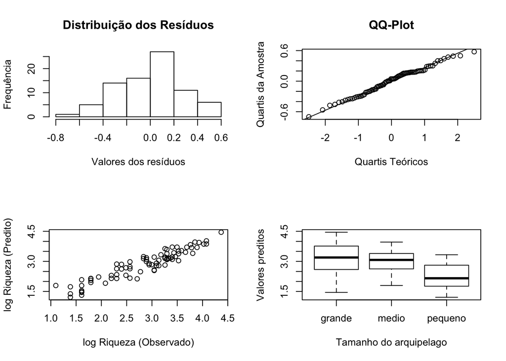

```r
par(mfrow = c(2,2))
hist(resid(modelo), xlab = "Valores dos resíduos", ylab = "Frequência", main = "Distribuição dos Resíduos")
qqnorm(resid(modelo), main = "QQ-Plot", xlab = "Quartis Teóricos", ylab = "Quartis da Amostra");qqline(resid(modelo))
plot(fitted(modelo) ~ log(riqueza), data = ilhas, xlab = "log Riqueza (Observado)", ylab = "log Riqueza (Predito)")
plot(fitted(modelo) ~ arquipelago, data = ilhas, xlab = "Tamanho do arquipelago", ylab = "Valores preditos")
```

### Após determinar o modelo adequado é que devemos realizar pós-testes e testes de significância dos termos no modelo

- Um exemplo de teste de significância dos termos do modelo:

```r
library(car)
Anova(modelo, type = "II") # existem três formas principais de calcular a significância dos termos em um modelo
```

```
## Analysis of Deviance Table (Type II tests)
##
## Response: log(riqueza)
##             LR Chisq Df Pr(>Chisq)
## arquipelago     8.05  2    0.01788 *
## log(area)     427.27  1    < 2e-16 ***
## habitat       260.39  1    < 2e-16 ***
## ---
## Signif. codes:  0 '***' 0.001 '**' 0.01 '*' 0.05 '.' 0.1 ' ' 1
```

- Um exemplo de pós-teste: existe diferenças na riqueza de espécies de acordo com o tamanho do arquipélago?

```r
library(lsmeans)
(teste1 <- lsmeans(object = modelo, "arquipelago"))
```

```
##  arquipelago   lsmean         SE df asymp.LCL asymp.UCL
##  grande      4.752846 0.10007844 NA  4.556696  4.948996
##  medio       4.723030 0.09397247 NA  4.538847  4.907212
##  pequeno     4.510755 0.12673546 NA  4.262358  4.759152
##
## Results are given on the identity (not the response) scale.
## Confidence level used: 0.95
```

```r
contrast(teste1, method = "pairwise")
```

```
##  contrast           estimate         SE df z.ratio p.value
##  grande - medio   0.02981638 0.07618482 NA   0.391  0.9190
##  grande - pequeno 0.24209146 0.09435139 NA   2.566  0.0278
##  medio - pequeno  0.21227508 0.08269093 NA   2.567  0.0277
##
## P value adjustment: tukey method for comparing a family of 3 estimates
```

### Uma observação: overdispersion, de novo

- Relembrando *overdispersion*: a estimativa do erro de um parâmetro é **subestimada** - a distribuição estatística prevê que a dispersão do conjunto de dados é menor do que o real.
- A *Deviance* seria uma medida do quanto os dados desviam do modelo implementado.
- Podemos obter evidência de **overdispersion** em um modelo de GLM através do cálculo entre a *Deviance* do modelo e o número de graus de liberdade dos resíduos.
- Se o valor de desta razão for maior do que 1, então existe evidência de **overdispersion** no modelo.
- Grosso modo: esta razão representa o quanto cada observação está contribuindo para o distanciamento entre os valores preditos pelo modelo e os valores observados.

deviance/df.residual > 1 = overdispersion

```r
modelo$deviance/modelo$df.residual
```

```
## [1] 0.07696979
```

- Este valor também é apresentado no `summary` do modelo.

```r
summary(modelo)
```

```
##
## Call:
## glm(formula = log(riqueza) ~ arquipelago + log(area) + habitat,
##     family = gaussian(), data = ilhas)
##
## Deviance Residuals:
##      Min        1Q    Median        3Q       Max
## -0.69892  -0.20023   0.04431   0.17751   0.57752
##
## Coefficients:
##                    Estimate Std. Error t value Pr(>|t|)
## (Intercept)         4.09553    0.11260  36.371   <2e-16 ***
## arquipelagomedio   -0.02982    0.07618  -0.391   0.6966
## arquipelagopequeno -0.24209    0.09435  -2.566   0.0123 *
## log(area)           0.37829    0.01830  20.671   <2e-16 ***
## habitat            -0.82436    0.05109 -16.137   <2e-16 ***
## ---
## Signif. codes:  0 '***' 0.001 '**' 0.01 '*' 0.05 '.' 0.1 ' ' 1
##
## (Dispersion parameter for gaussian family taken to be 0.07696979)
##
##     Null deviance: 48.1062  on 79  degrees of freedom
## Residual deviance:  5.7727  on 75  degrees of freedom
## AIC: 28.72
##
## Number of Fisher Scoring iterations: 2
```

## Um exemplo de modelo linear misto

- Suponha que o efeito do tamanho do arquipélago não seja de nosso interesse na análise de dados, e que tenhamos amostrado um subconjunto de todos os tamanhos de arquipélago possível que exista.
- Neste caso, utilizaremos um modelo muito similar ao que já rodamos, mas incluiremos o tamanho do arquipelago como um termo aleatorio no modelo.
- Para os modelos gerados através das funções do pacote `lme4`, existem opções de funções que ajudam na seleção e validação de modelos no pacote `lmerTest`.
- O pacote `lme4` possui muitas funcionalidades, mas algumas delas são *temperamentais* (existe a alternativa do pacote `nlme`)

```r
library(lme4)
library(lmerTest)
ilhas$logarea <- log(ilhas$area)
modelo <- lmer(formula = log(riqueza) ~ (1|arquipelago) + logarea + produtividade + populacao + habitat + montanha + temperatura + precipitacao,
               data = ilhas)
summary(modelo)
```

```
## Linear mixed model fit by REML t-tests use Satterthwaite approximations
##   to degrees of freedom [lmerMod]
## Formula: log(riqueza) ~ (1 | arquipelago) + logarea + produtividade +
##     populacao + habitat + montanha + temperatura + precipitacao
##    Data: ilhas
##
## REML criterion at convergence: 110.9
##
## Scaled residuals:
##      Min       1Q   Median       3Q      Max
## -2.31637 -0.77405  0.01854  0.69449  1.79953
##
## Random effects:
##  Groups      Name        Variance Std.Dev.
##  arquipelago (Intercept) 0.01325  0.1151
##  Residual                0.08149  0.2855
## Number of obs: 80, groups:  arquipelago, 3
##
## Fixed effects:
##                 Estimate Std. Error         df t value Pr(>|t|)
## (Intercept)    4.040e+00  2.107e-01  4.639e+01  19.175   <2e-16 ***
## logarea        3.845e-01  1.922e-02  7.197e+01  20.002   <2e-16 ***
## produtividade -3.666e-09  2.329e-07  7.013e+01  -0.016    0.987
## populacao      1.044e-04  2.146e-04  6.995e+01   0.487    0.628
## habitat       -8.234e-01  5.951e-02  7.139e+01 -13.835   <2e-16 ***
## montanhasim   -4.305e-02  1.089e-01  7.034e+01  -0.395    0.694
## temperatura   -4.044e-03  5.667e-03  7.197e+01  -0.713    0.478
## precipitacao   8.770e-06  5.696e-05  7.033e+01   0.154    0.878
## ---
## Signif. codes:  0 '***' 0.001 '**' 0.01 '*' 0.05 '.' 0.1 ' ' 1
##
## Correlation of Fixed Effects:
##             (Intr) logare prdtvd populc habitt mntnhs tmprtr
## logarea      0.291
## produtividd  0.117 -0.123
## populacao   -0.395 -0.085 -0.051
## habitat     -0.461 -0.609 -0.112  0.177
## montanhasim  0.022 -0.204  0.153 -0.052 -0.479
## temperatura -0.434 -0.019 -0.124 -0.171 -0.106  0.111
## precipitaca -0.500  0.059  0.071  0.068 -0.082  0.165  0.055
## fit warnings:
## Some predictor variables are on very different scales: consider rescaling
```

- Podemos realizar a seleção de modelos através da função `lmerTest::step` ou ainda através da função `MuMin::dredge`.

```r
step(model = modelo, lsmeans.calc = FALSE, difflsmeans.calc = FALSE, alpha.random = 0.1, alpha.fixed = 0.05)
```

```
##
## Random effects:
##             Chi.sq Chi.DF elim.num p.value
## arquipelago   2.75      1     kept   0.097
##
## Fixed effects:
##                Sum Sq Mean Sq NumDF DenDF  F.value elim.num Pr(>F)
## montanha       0.0127  0.0127     1 70.34   0.1564        1 0.6937
## produtividade  0.0002  0.0002     1 71.04   0.0021        2 0.9632
## precipitacao   0.0039  0.0039     1 72.41   0.0497        3 0.8242
## populacao      0.0168  0.0168     1 73.04   0.2136        4 0.6453
## temperatura    0.0308  0.0308     1 76.00   0.3975        5 0.5303
## logarea       34.9587 34.9587     1 76.79 453.5450     kept <1e-07
## habitat       21.8153 21.8153     1 75.70 283.0264     kept <1e-07
##
## Final model:
## lme4::lmer(formula = log(riqueza) ~ (1 | arquipelago) + logarea +
##     habitat, data = ilhas, contrasts = list())
```

```r
dredge(modelo)
```

```
## Fixed term is "(Intercept)"
```

```
## Global model call: lme4::lmer(formula = log(riqueza) ~ (1 | arquipelago) + logarea +
##     produtividade + populacao + habitat + montanha + temperatura +
##     precipitacao, data = ilhas)
## ---
## Model selection table
##     (Intrc)    habtt  logar mntnh     poplc      prcpt      prdtv
## 4     4.038 -0.84020 0.3832
## 8     4.029 -0.83130 0.3844     +
## 68    4.098 -0.83820 0.3834
## 72    4.092 -0.82700 0.3849     +
## 12    4.008 -0.83780 0.3827       7.127e-05
## 20    4.016 -0.84020 0.3836                  1.221e-05
## 16    3.998 -0.82860 0.3839     + 7.353e-05
## 24    4.013 -0.83210 0.3847     +            9.691e-06
## 76    4.065 -0.83470 0.3826       9.683e-05
```

[output cut: 251 more lines]

- O teste de significância dos termos do modelo deve ser feito com a função `lmerTest::Anova`.

```r
modelo <- lmer(formula = log(riqueza) ~ (1|arquipelago) + logarea + habitat, data = ilhas)
Anova(modelo, type = 2)
```

```
## Analysis of Deviance Table (Type II Wald chisquare tests)
##
## Response: log(riqueza)
##          Chisq Df Pr(>Chisq)
## logarea 453.55  1  < 2.2e-16 ***
## habitat 283.03  1  < 2.2e-16 ***
## ---
## Signif. codes:  0 '***' 0.001 '**' 0.01 '*' 0.05 '.' 0.1 ' ' 1
```

## Considerações finais

- Rodar um modelo é parte ciência, parte arte, e exige muito mais trabalho do que apenas as noções apresentadas aqui;
- Existem muitos tipos e opções de modelos estatísticos:
  - Modelos lineares:
    - `base::lm`, `base::glm`
    - `nlme::lme`, `nlme::gls`
    - `lme4::lmer`, `lme4::glmer`
    - `gam::gam`
  - Modelos não-lineares:
    - `stats::nls`, `stats:loess`
    - `nlme::gnls`
    - `gnm::gnm`
    - `gam::gam`
- Não existe o melhor modelo ou a melhor distribuição para um conjunto de dados, mas sim aquele modelo ou distribuição que melhor se adequa à sua pergunta e objetivos.